# Data Wrangling

For Stoat control in Beech forest paper

Anthony Davidson

2019-05-16

# Overview

This report investigates the estimation of the raw observations. The data is in a similar structure as historically used for estimation of food availability (Choquenot and Ruscoe 2000; Ruscoe, Goldsmith, and Choquenot 2001; Ruscoe et al. 2005).

# Introduction and Methods

*Generally look at thesis drafts here.*

This RMarkdown file is intend to be extended on for different species of trees, fruit and seed. These files are the supporting documetation to the data-wrangling code in the Beech forest manuscript here.

Bbut there is also many other supporting resources and less formal tutorials on my [website](https://www.ssnhub.com) and the feed below:

## Invasive species notes

```r
# {% for post in site.tags["invasive-spp"] %}
#   <a href="{{ post.url }}">{{ post.title }}</a> ({{ post.date | date_to_string }})<br>
#     {{ post.description }}
# {% endfor %}
```

## Meta-data

- [Current draft](https://www.dropbox.com/home/phd-drafts-anthony/beech-forest-dynamics/drafts/Davidson_2019_BeechForest.html)
- [Style sheet](https://www.dropbox.com/home/phd-drafts-anthony/beech-forest-dynamics/Styles_manual_sheet.md/)
- [Introduction](https://www.dropbox.com/sh/5h4mp67p7u6t1lj/AAAQVKS4qnvu2oQLu53JQUofa?dl=0)
- [Bayesian methods](https://www.dropbox.com/home/phd-drafts-anthony/beech-forest-dynamics/A1_full_bayesian_model.pdf)
- [Figures](https://www.dropbox.com/home/phd-drafts-anthony/beech-forest-dynamics/figs)
- [Functional response](https://www.dropbox.com/home/phd-drafts-anthony/beech-forest-dynamics/Davidson_2019_BeechForest_Appendix.pdf)
- References: *coming online soon*

All other data and resources to render project from raw data (copied from my private GIT repository) can be found on [dropbox](https://www.dropbox.com/home/phd-drafts-anthony) but will be available here when I have incorporated the co-authors feedback

```r
# {% for post in site.tags["invasive-spp"] %}
#   <a href="{{ post.url }}">{{ post.title }}</a> ({{ post.date | date_to_string }})<br>
#     {{ post.description }}
# {% endfor %}
```

## Variable structure

I have defined the following parameters that help to keep the type of variable the same throughout the joining of the raw data and the model outputs.

### Group levels

*But in short*

#### Labels/levels

*all mixed up* **still**

```r
#month levels to get it right
month_levels <- c("Jan", "Feb", "Mar", "Apr", "May", "Jun","Jul", "Aug", "Sep", "Oct", "Nov", "Dec")

# full set of dates
true.date <- as.Date(c("1999-05-01","1999-08-01","1999-11-01","2000-02-01","2000-05-01","2000-08-01","2000-11-01","2001-02-01","2001-05-01","2001-08-01", "2001-11-01","2002-05-01","2002-11-01","2003-02-01","2003-05-01","2003-08-01","2003-11-01","2004-02-01","2004-05-01","2004-08-01"))

# Grid labels
labels <- c("egl M1" = "Grid one",
            "egl M2" = "Grid two",
            "egl MR1" = "Grid three",
            "egl MR2" = "Grid four",
            "hol M1" = "Grid five",
            "hol M2" = "Grid six",
            "hol MR1" = "Grid seven",
            "hol MR2" = "Grid eight")

# Valley labels
labels2 <- c(egl = "Eglinton valley", hol = "Hollyford valley")
```

##### Full treatment

**6 levels**

```r
treat.six.levels <- c("hol no control rats.removed",
                                     "hol control rats.present",
                                     "hol control rats.removed",
                                     "egl control rats.present",
                                     "egl control rats.removed" ,
                                     "hol no control rats.present")
```

In this the structure of the variables for the seed dataset have to be joint and visualised we need to insure that there are the same number of replicates in this dataset as the output dataset (from the JAGS model).

##### Still coming out of wash

COntrol labels - Stoats yes/no

Conditions labals - Rats yes/no

### Seasonal factorisation

In the data the seasonal parameter is month where:

| Month | Season | Factor level |
| --- | --- | --- |
| February | Summer | 1 |
| May | Autumn | 2 |
| August | Winter | 3 |
| November | Spring | 4 |

# Seeds

This is important because the following bias are known and need to be accounted for before analysising data.

1. Seeds without the kernal have no energy value and need to be removed.
2. Different beech species produce different sized seeds and this has an effect on the “available seed”.
3. As our models build in complexity we will include a variety of food resources and therefore need to model these relationships in the future

## Importing data

The orginal data was in excel format and manually covered to csv as below. This has had the non-viable material removed and only whole kernals of seed for three species of beech tree were reported.

### Seed Measurement

The data is very clean with all the information but to make life simplier for the analysis and bindng to output data to be correct.

#### Method - `metre sq (m2)`

1. `Bucket radius = 0.125m`
2. `Bucket area = 0.049087385m2`
3. `4 buckets per grid = total catch area = 0.19635 m2`
4. `So seeds /m2 =# Seeds counted/0.1963`

Therefore, if $800$ seeds were counted on a grid on a particular trip, this will equate to $4000 m^2$.

### Find extra trips and grids

### Remove additional data

## Final seed dataset

This is the full raw data reduction for the publication and in all the analysis. This data is lagged by a single trip (as a proxy for seed to “intake rate” relationship). Descriptive plots can be found in appendix.

| valley | red | silver | seedm2 | grid.id | grid | trip.no | year | month | total | cum.seed | trip | log.cum.seed |
| --- | --- | --- | --- | --- | --- | --- | --- | --- | --- | --- | --- | --- |
| egl | 81 | 31 | 590.781767 | M1 | egl M1 | 1 | 1999 | May | 116 | 590.781767 | 1 | 2.7721616 |
| egl | 5 | 1 | 30.557678 | M1 | egl M1 | 2 | 1999 | Aug | 6 | 621.339445 | 2 | 2.7940273 |
| egl | 1 | 0 | 10.185893 | M1 | egl M1 | 3 | 1999 | Nov | 2 | 631.525337 | 3 | 2.8010779 |
| egl | 0 | 0 | 20.371785 | M1 | egl M1 | 4 | 2000 | Feb | 4 | 20.371785 | 4 | 1.3298408 |
| egl | 222 | 31 | 1303.794245 | M1 | egl M1 | 5 | 2000 | May | 256 | 1324.166030 | 5 | 3.1222703 |
| egl | 48 | 26 | 376.878024 | M1 | egl M1 | 6 | 2000 | Aug | 74 | 1701.044054 | 6 | 3.2309708 |
| egl | 1 | 2 | 15.278839 | M1 | egl M1 | 7 | 2000 | Nov | 3 | 1716.322893 | 7 | 3.2348520 |
| egl | 0 | 0 | 0.000000 | M1 | egl M1 | 8 | 2001 | Feb | 0 | 0.000000 | 8 | 0.0000000 |
| egl | 0 | 0 | 0.000000 | M1 | egl M1 | 9 | 2001 | May | 0 | 0.000000 | 9 | 0.0000000 |
| egl | 0 | 0 | 0.000000 | M1 | egl M1 | 10 | 2001 | Aug | 0 | 0.000000 | 10 | 0.0000000 |

[output cut: 134 more lines]

# Mice

The mouse dataset is generated from the full CR model found here

## Import data

The seed data above needs to be joined to the mouse dataset below. I will step through this process to insure that there are no errors in the merging of the two datasets.

### JAGS output

The output data of the model is in JAGS format. This means that it needs to be converted into a `dataframe` format. There are many different ways to do this. I have choosen the following tidy approach.

We save and sort the bayesian model outputs in a `.rds` file and extract these results using:

*JAGSui output* (Kellner 2018).

#### Naming variable

#### Extract only N

## Restructuring dataset

### Adding grouping variables

### Reduced seed joining dataset

Check the structure of this to make sure that the variables being joined are being correctly merged.

| grid | trip | year | month | cum.seed | valley |
| --- | --- | --- | --- | --- | --- |
| egl M1 | 1 | 1999 | May | 590.781767 | egl |
| egl M1 | 2 | 1999 | Aug | 621.339445 | egl |
| egl M1 | 3 | 1999 | Nov | 631.525337 | egl |
| egl M1 | 4 | 2000 | Feb | 20.371785 | egl |
| egl M1 | 5 | 2000 | May | 1324.166030 | egl |
| egl M1 | 6 | 2000 | Aug | 1701.044054 | egl |
| egl M1 | 7 | 2000 | Nov | 1716.322893 | egl |
| egl M1 | 8 | 2001 | Feb | 0.000000 | egl |
| egl M1 | 9 | 2001 | May | 0.000000 | egl |
| egl M1 | 10 | 2001 | Aug | 0.000000 | egl |

[output cut: 134 more lines]

### Joining seed and mice

# Stoat control

**control variable**

# Rat removal

**treatment variable**

# More grouping options

# Re-leveling dataset

Just a final check that everything has worked.

# Saved datasets

I will save the final dataset for the analysis of the Beech foret data for the publication as so: The final plots. All extended plots are in the `Rcode/figures/`. These plots focus on simplifying the general trends and confirming any previous predictions.

## Study design

CR-design is complex and when treatments and conditions change through time it can be very hard to explain the data collection methods well. We have therefore constructed a diagram of the study design process.

### Data

| N | se.N | lcl.N | ucl.N | var | grid | trip | grid.n | trip.no | valley | control | Valley | year | month | cum.seed | seed.account.N | log.seed | valley.rep | grid.rats | Conditions | grouping.1 | grouping.2 | grouping.3 | grouping.4 | true.date | treat.six | Rats | Control | Date | Treatments | … |
| --- | --- | --- | --- | --- | --- | --- | --- | --- | --- | --- | --- | --- | --- | --- | --- | --- | --- | --- | --- | --- | --- | --- | --- | --- | --- | --- | --- | --- | --- | --- |
| 85.18592 | 17.258336 | 53 | 114 | N[1,1] | 1 | 1 | 1 | 1 | egl | control | Eglinton | 1999 | May | 590.78177 | 6.9352044 | 2.771427 | egl | M1 | rats.removed | treat.highN | treat.highN | treat.highN | treat.highN | 1999-05-01 | egl control rats.removed | Reduced | Yes | 1999-05-01 | egl control rats.removed | … |
| 141.34645 | 24.813696 | 103 | 200 | N[2,1] | 1 | 2 | 1 | 2 | egl | control | Eglinton | 1999 | Aug | 621.33944 | 4.3958616 | 2.793329 | egl | M1 | rats.removed | treat.highN | treat.highN | treat.highN | treat.highN | 1999-08-01 | egl control rats.removed | Reduced | Yes | 1999-08-01 | egl control rats.removed | … |
| 125.54291 | 15.717429 | 100 | 162 | N[3,1] | 1 | 3 | 1 | 3 | egl | control | Eglinton | 1999 | Nov | 631.52534 | 5.0303546 | 2.800391 | egl | M1 | rats.removed | treat.highN | treat.highN | treat.highN | treat.highN | 1999-11-01 | egl control rats.removed | Reduced | Yes | 1999-11-01 | egl control rats.removed | … |
| 23.76927 | 1.661358 | 22 | 28 | N[4,1] | 1 | 4 | 1 | 4 | egl | control | Eglinton | 2000 | Feb | 20.37179 | 0.8570639 | 1.309029 | egl | M1 | rats.removed | treat.lowN | treat.highN | treat.highN | treat.highN | 2000-02-01 | egl control rats.removed | Reduced | Yes | 2000-02-01 | egl control rats.removed | … |
| 89.53025 | 18.540501 | 57 | 125 | N[5,1] | 1 | 5 | 1 | 5 | egl | control | Eglinton | 2000 | May | 1324.16603 | 14.7901517 | 3.121942 | egl | M1 | rats.removed | treat.highN | treat.highN | treat.highN | treat.highN | 2000-05-01 | egl control rats.removed | Reduced | Yes | 2000-05-01 | egl control rats.removed | … |
| 132.57411 | 24.562060 | 88 | 179 | N[6,1] | 1 | 6 | 1 | 6 | egl | control | Eglinton | 2000 | Aug | 1701.04405 | 12.8308914 | 3.230716 | egl | M1 | rats.removed | treat.highN | treat.highN | treat.highN | treat.highN | 2000-08-01 | egl control rats.removed | Reduced | Yes | 2000-08-01 | egl control rats.removed | … |

### Plot

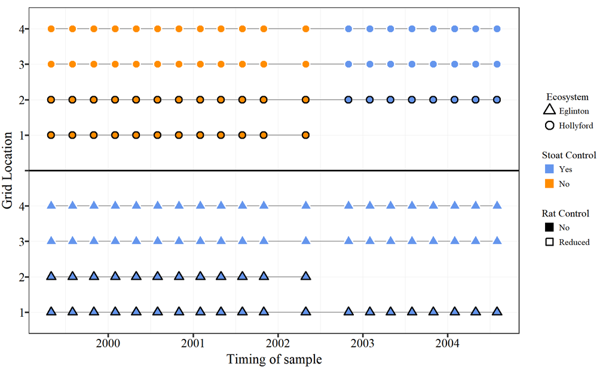

### Saving

## Seed

### Data

| Control | Valley | Date | mean.s | sd.s | se.s | lcl.s | ucl.s |
| --- | --- | --- | --- | --- | --- | --- | --- |
| Yes | Eglinton | 1999-05-01 | 1215.94092 | 717.09184 | 702.75000 | 513.1909202 | 1918.69092 |
| Yes | Eglinton | 1999-08-01 | 1549.52890 | 1051.30694 | 1030.28081 | 519.2480975 | 2579.80971 |
| Yes | Eglinton | 1999-11-01 | 1567.35421 | 1066.08050 | 1044.75889 | 522.5953206 | 2612.11311 |
| Yes | Eglinton | 2000-02-01 | 12.73237 | 12.12364 | 11.88116 | 0.8512013 | 24.61353 |
| Yes | Eglinton | 2000-05-01 | 1466.76853 | 891.76505 | 873.92975 | 592.8387756 | 2340.69828 |
| Yes | Eglinton | 2000-08-01 | 1884.39012 | 1076.85007 | 1055.31307 | 829.0770540 | 2939.70319 |

### Plot

#### All seed data

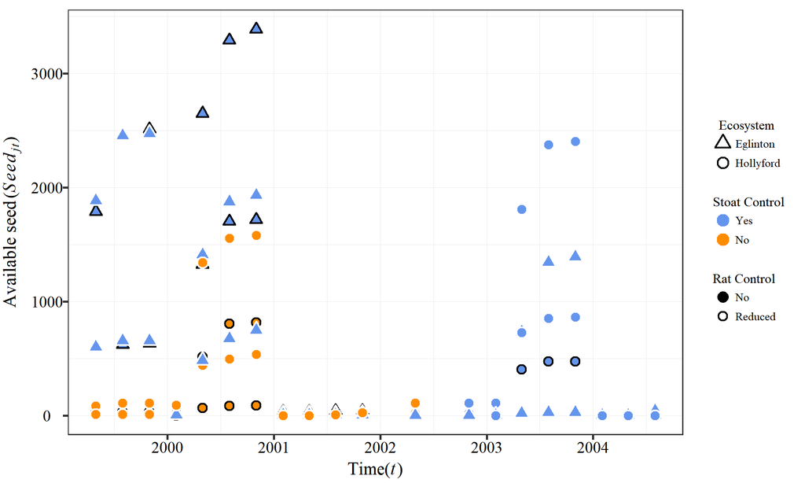

#### Summarising

I have done this by grouping dataset into the three key treatments (with and without stoat control in the Hollyford Valley and stoat control in the Eglinton Valley).

| Control | Valley | Date | N | Rats | sd.s | se.s | lcl.s | lcl.slog | ucl.s | ucl.slog | cum.seed | grid |
| --- | --- | --- | --- | --- | --- | --- | --- | --- | --- | --- | --- | --- |
| Yes | Eglinton | 1999-05-01 | 1215.94092 | Full | 717.09184 | 702.75000 | 513.1909202 | NA | 1918.69092 | NA | 1215.94092 | Yes Eglinton |
| Yes | Eglinton | 1999-08-01 | 1549.52890 | Full | 1051.30694 | 1030.28081 | 519.2480975 | NA | 2579.80971 | NA | 1549.52890 | Yes Eglinton |
| Yes | Eglinton | 1999-11-01 | 1567.35421 | Full | 1066.08050 | 1044.75889 | 522.5953206 | NA | 2612.11311 | NA | 1567.35421 | Yes Eglinton |
| Yes | Eglinton | 2000-02-01 | 12.73237 | Full | 12.12364 | 11.88116 | 0.8512013 | NA | 24.61353 | NA | 12.73237 | Yes Eglinton |
| Yes | Eglinton | 2000-05-01 | 1466.76853 | Full | 891.76505 | 873.92975 | 592.8387756 | NA | 2340.69828 | NA | 1466.76853 | Yes Eglinton |
| Yes | Eglinton | 2000-08-01 | 1884.39012 | Full | 1076.85007 | 1055.31307 | 829.0770540 | NA | 2939.70319 | NA | 1884.39012 | Yes Eglinton |

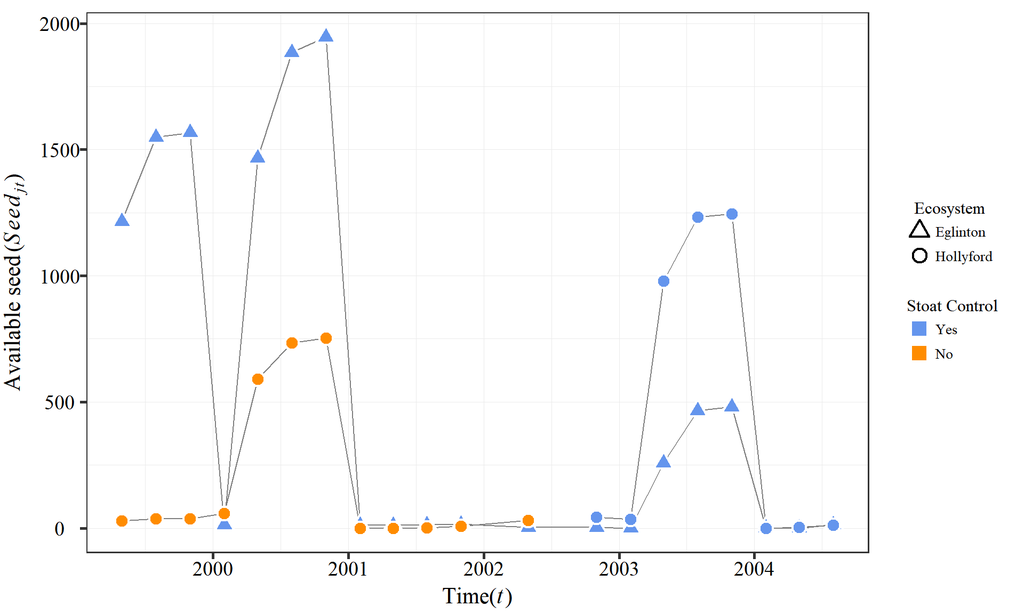

##### Raw confidence intervals

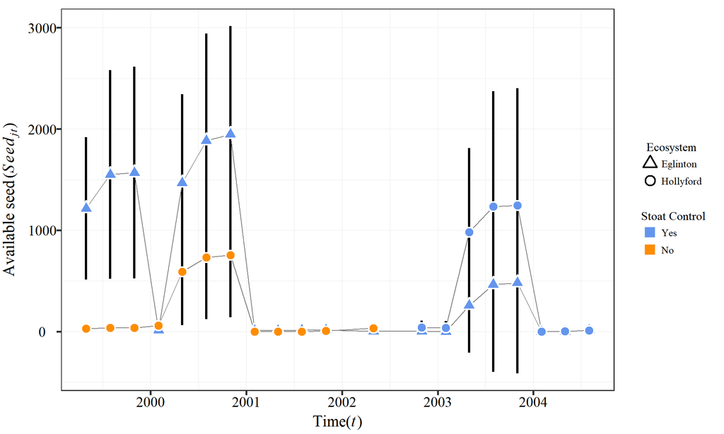

##### Log transformation to remove less and zero seed…

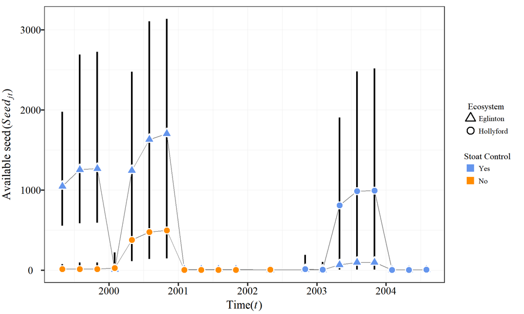

##### Combing plots

Orginal data seems too messy so have reverted to the summary plot above.

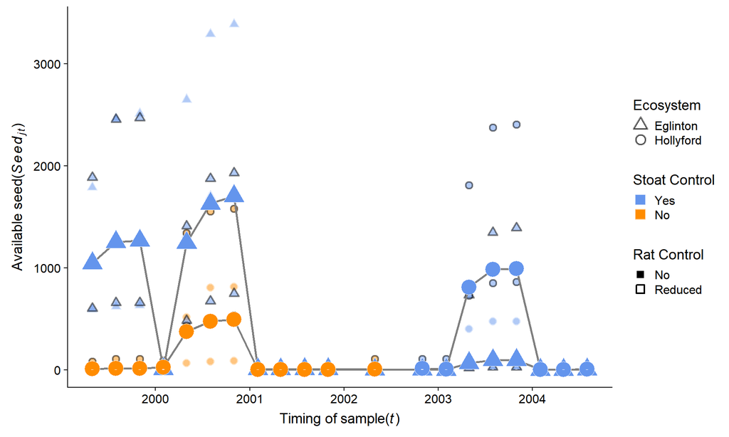

##### Final plot

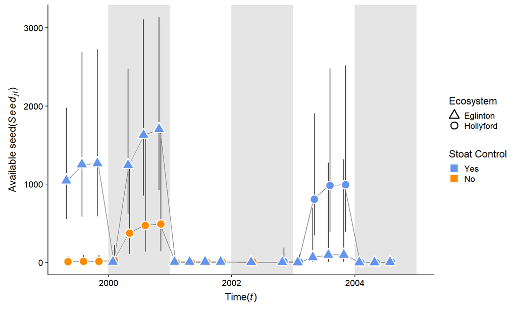

### Saving

#### Data

#### Figure

## Mice

### Data

| Control | Valley | Date | mean.s | sd.s | se.s | lcl.s | ucl.s | gp.treat | N | Rats |
| --- | --- | --- | --- | --- | --- | --- | --- | --- | --- | --- |
| Yes | Eglinton | 1999-05-01 | 52.52743 | 27.308946 | 26.762767 | 25.76466 | 79.29020 | Eglinton Yes | 52.52743 | Full |
| Yes | Eglinton | 1999-08-01 | 165.56351 | 59.608474 | 58.416304 | 107.14721 | 223.97981 | Eglinton Yes | 165.56351 | Full |
| Yes | Eglinton | 1999-11-01 | 105.38420 | 36.525855 | 35.795338 | 69.58886 | 141.17954 | Eglinton Yes | 105.38420 | Full |
| Yes | Eglinton | 2000-02-01 | 25.23375 | 6.496038 | 6.366117 | 18.86763 | 31.59986 | Eglinton Yes | 25.23375 | Full |
| Yes | Eglinton | 2000-05-01 | 55.47290 | 27.866482 | 27.309153 | 28.16375 | 82.78205 | Eglinton Yes | 55.47290 | Full |
| Yes | Eglinton | 2000-08-01 | 128.91481 | 33.675592 | 33.002080 | 95.91273 | 161.91689 | Eglinton Yes | 128.91481 | Full |

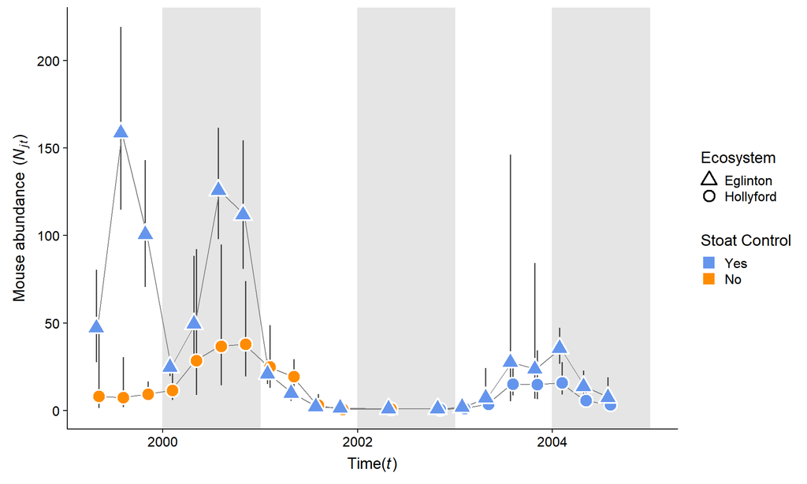

### Saving

## Rats

### Data

```
Observations: 144
Variables: 35
$ N              <dbl> 85.185920, 141.346453, 125.542907, 23.769273, 8...
$ se.N           <dbl> 17.258336, 24.813696, 15.717429, 1.661358, 18.5...
$ lcl.N          <dbl> 53, 103, 100, 22, 57, 88, 93, 25, 13, 0, 1, 1, ...
$ ucl.N          <dbl> 114, 200, 162, 28, 125, 179, 164, 43, 26, 5, 5,...
$ var            <chr> "N[1,1]", "N[2,1]", "N[3,1]", "N[4,1]", "N[5,1]...
$ grid           <chr> "egl M1", "egl M1", "egl M1", "egl M1", "egl M1...
$ trip           <chr> "1", "2", "3", "4", "5", "6", "7", "8", "9", "1...
$ grid.n         <dbl> 1, 1, 1, 1, 1, 1, 1, 1, 1, 1, 1, 1, 1, 1, 1, 1,...
$ trip.no.x      <dbl> 1, 2, 3, 4, 5, 6, 7, 8, 9, 10, 11, 12, 13, 14, ...
$ valley.x       <chr> "egl", "egl", "egl", "egl", "egl", "egl", "egl"...
$ control        <chr> "control", "control", "control", "control", "co...
$ Valley         <fct> Eglinton, Eglinton, Eglinton, Eglinton, Eglinto...
$ year           <dbl> 1999, 1999, 1999, 2000, 2000, 2000, 2000, 2001,...
```

[output cut: 22 more lines]

| Control | Valley | Date | mean.rat | sd.rat | se.rat | lcl.rat | ucl.rat | gp.treat | N | Rats |
| --- | --- | --- | --- | --- | --- | --- | --- | --- | --- | --- |
| Yes | Eglinton | 1999-05-01 | 1.333333 | 0.5773503 | 0.5658033 | 0.7675301 | 1.899137 | Eglinton Yes | 1.333333 | Full |
| Yes | Eglinton | 1999-08-01 | 2.250000 | 1.2583057 | 1.2331396 | 1.0168604 | 3.483140 | Eglinton Yes | 2.250000 | Full |
| Yes | Eglinton | 1999-11-01 | 8.000000 | 4.5460606 | 4.4551394 | 3.5448606 | 12.455139 | Eglinton Yes | 8.000000 | Full |
| Yes | Eglinton | 2000-02-01 | 1.500000 | 0.7071068 | 0.6929646 | 0.8070354 | 2.192965 | Eglinton Yes | 1.500000 | Full |
| Yes | Eglinton | 2000-05-01 | 2.666667 | 2.0816660 | 2.0400327 | 0.6266340 | 4.706699 | Eglinton Yes | 2.666667 | Full |
| Yes | Eglinton | 2000-08-01 | 1.500000 | 0.5773503 | 0.5658033 | 0.9341967 | 2.065803 | Eglinton Yes | 1.500000 | Full |

### Plot

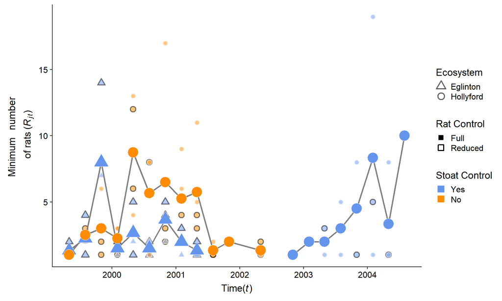

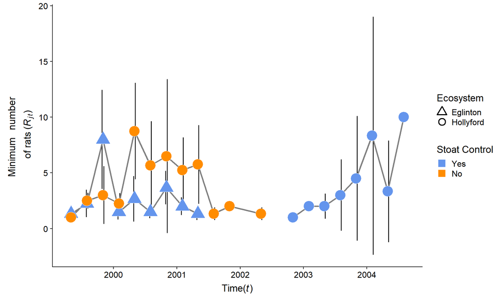

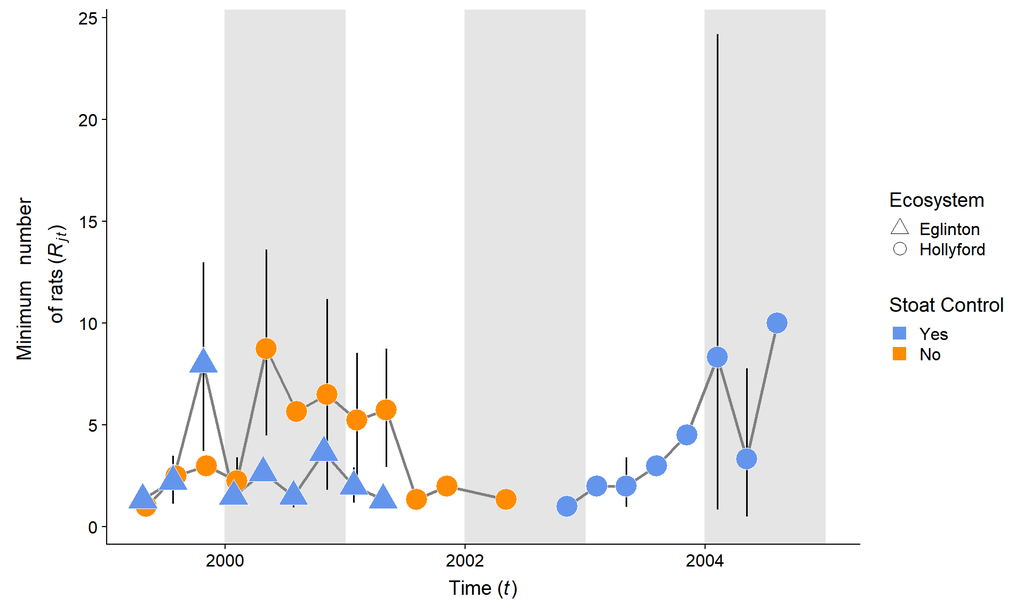

### Saving

# References

Choquenot, David, and Wendy A Ruscoe. 2000. “Mouse Population Eruptions in New Zealand Forests: The Role of Population Density and Seedfall.” *Journal of Animal Ecology* 69: 1058–70.

Kellner, Ken. 2018. *jagsUI: A Wrapper Around ’Rjags’ to Streamline ’JAGS’ Analyses*.

King, Carolyn M. 1983. “The Relationships Between Beech (Nothofagus Sp.) Seedfall and Populations of Mice (Mus Musculus), and the Demographic and Dietary Responses of Stoats (Mustela Erminea), in Three New Zealand Forests.” *Journal of Animal Ecology* 52 (1): 141–66.

Ruscoe, Wendy A, Joseph S Elkinton, David Choquenot, and Robert B Allen. 2005. “Predation of Beech Seed by Mice: Effects of Numerical and Functional Responses.” *Journal of Animal Ecology* 74: 1005–19. https://doi.org/10.1111/j.1365-2656.2005.00998.x.

Ruscoe, Wendy A, Ruth Goldsmith, and David Choquenot. 2001. “A Comparison of Population Estimates and Abundance Indices for House Mice Inhabiting Beech Forests in New Zealand.” *Wildlife Research* 28: 173–78.

Wardle, P. 1991. *Vegetation of New Zealand*. Cambridge University Press.